# Lab 9: Data joining and maps

Elena Tuzhilina

Oct 19, 2021

## Getting started: drawing a map of the USA

Let’s start by drawing a map of the USA. The `maps` package contains a lot of outlines of continents, countries, states, and counties. `ggplot2`’s `map_data` function puts these outlines in data frame format, which then allows us to plot them with `ggplot`.

Let’s load the packages that we need:

```r
library(tidyverse)
library(maps)
```

Type in the following code:

```r
map_USA <- map_data("usa")
head(map_USA)
```

```
##        long      lat group order region subregion
## 1 -101.4078 29.74224     1     1   main      <NA>
## 2 -101.3906 29.74224     1     2   main      <NA>
## 3 -101.3620 29.65056     1     3   main      <NA>
## 4 -101.3505 29.63911     1     4   main      <NA>
## 5 -101.3219 29.63338     1     5   main      <NA>
## 6 -101.3047 29.64484     1     6   main      <NA>
```

(If the code above doesn’t work, it could be that the `maps` package has not been installed yet. Install the `maps` package and try the code above again.) Each row in the `map_USA` dataset is one point on the outline of the USA. We are going to use `ggplot2`’s `geom_polygon` to connect these points.

It terms out that you can’t draw a map of the US with just one polygon: there are islands (e.g. Long Island) which form separate polygons. To draw just the “main” mainland, filter as follows:

```r
map_USA_main <- map_USA %>% filter(region == "main")
```

In the same code chunk, type the following code:

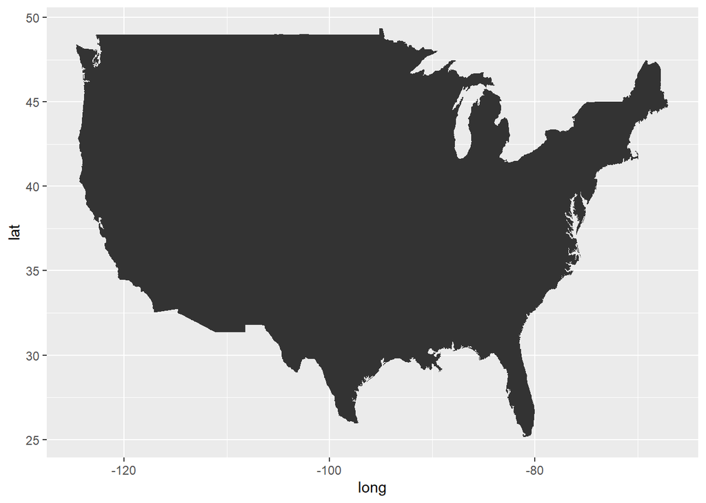

```r
ggplot() +
    geom_polygon(data = map_USA_main, mapping = aes(x = long, y = lat))
```

We get a map! By default, the fill of the polygon is black. Click on the “Zoom” button and resize the window. Do you notice what happens to the map?

In order to keep the correct aspect ratio, amend the code for the map by adding on an extra line:

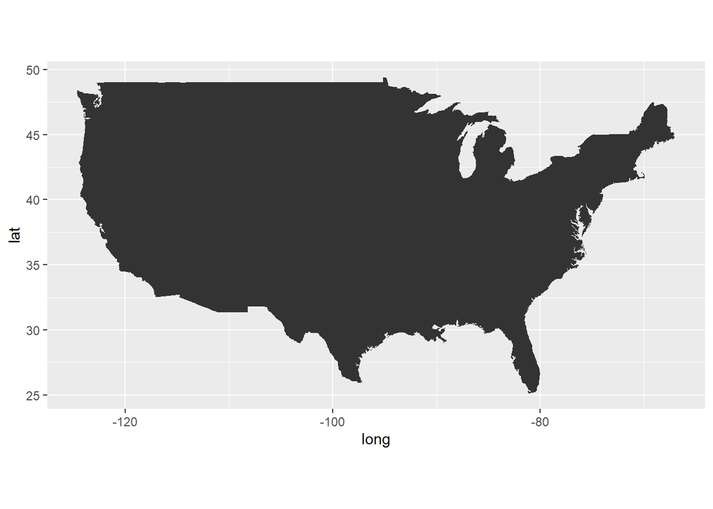

```r
ggplot() +
    geom_polygon(data = map_USA_main, mapping = aes(x = long, y = lat)) +
    coord_quickmap()
```

Try resizing the window and see the difference in behavior from before.

## County map

Let’s try to draw a county-level map. For the later part of this lab, we want to label these counties by FIPS codes (you can read more about FIPS county codes [here](https://en.wikipedia.org/wiki/FIPS_county_code)). It turns out that it’s not so easy to get mapping data with FIPS codes, so I’ve put together a dataset to save you this trouble. Load it with the following code:

```r
map_county_fips <- readRDS("county_map_fips.rds")
head(map_county_fips)
```

```
##        long      lat group order  region subregion fips
## 1 -86.50517 32.34920     1     1 alabama   autauga 1001
## 2 -86.53382 32.35493     1     2 alabama   autauga 1001
## 3 -86.54527 32.36639     1     3 alabama   autauga 1001
## 4 -86.55673 32.37785     1     4 alabama   autauga 1001
## 5 -86.57966 32.38357     1     5 alabama   autauga 1001
## 6 -86.59111 32.37785     1     6 alabama   autauga 1001
```

Let’s draw a county map using code that’s very similar to what we had for drawing the map of the USA:

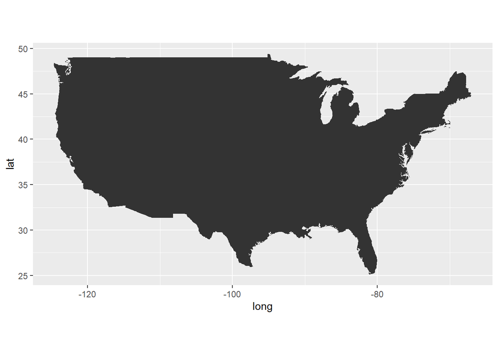

```r
ggplot() +
    geom_polygon(data = map_county_fips,
                 mapping = aes(x = long, y = lat, group = group)) +
    coord_quickmap()
```

Now, let’s draw a map with black outlines for the counties, and different colors for each state:

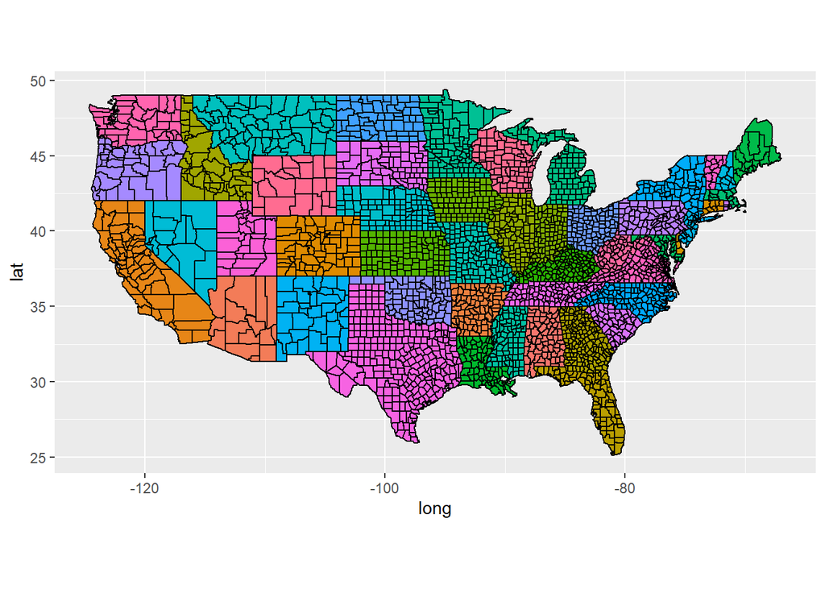

```r
ggplot() +
    geom_polygon(data = map_county_fips,
                 mapping = aes(x = long, y = lat, group = group, fill = region),
                 col = "black") +
    coord_quickmap() +
    theme(legend.position="none")
```

## Elections data

The goal of the rest of this lab is to visualize the 2016 US presidential elections results on a county-level map. Let’s load the elections data and have a peek at it:

```r
df <- read_csv("2016_US_Presdential_Results_for_class.csv")
head(df)
```

```
## # A tibble: 6 x 7
##    fips percent_diff state county votes_dem votes_gop total_votes
##   <dbl>        <dbl> <chr> <chr>      <dbl>     <dbl>       <dbl>
## 1  2013         15.2 AK    Alaska     93003    130413      246588
## 2  2016         15.2 AK    Alaska     93003    130413      246588
## 3  2020         15.2 AK    Alaska     93003    130413      246588
## 4  2050         15.2 AK    Alaska     93003    130413      246588
## 5  2060         15.2 AK    Alaska     93003    130413      246588
## 6  2068         15.2 AK    Alaska     93003    130413      246588
```

In order to have the fills of the counties depend on our elections data, we need to somehow get information from our `df` dataset to the `map_county_fips` dataset. We can achieve this by using `dplyr`’s **left-join**.

The code below joins the two data frames on the `fips` column (`map_county_fips` is on the left, `df` is on the right):

```r
# join elections data to mapping data
map_county_per_diff <- map_county_fips %>%
    left_join(df, by = "fips")
```

Next, we use `ggplot` to plot the data:

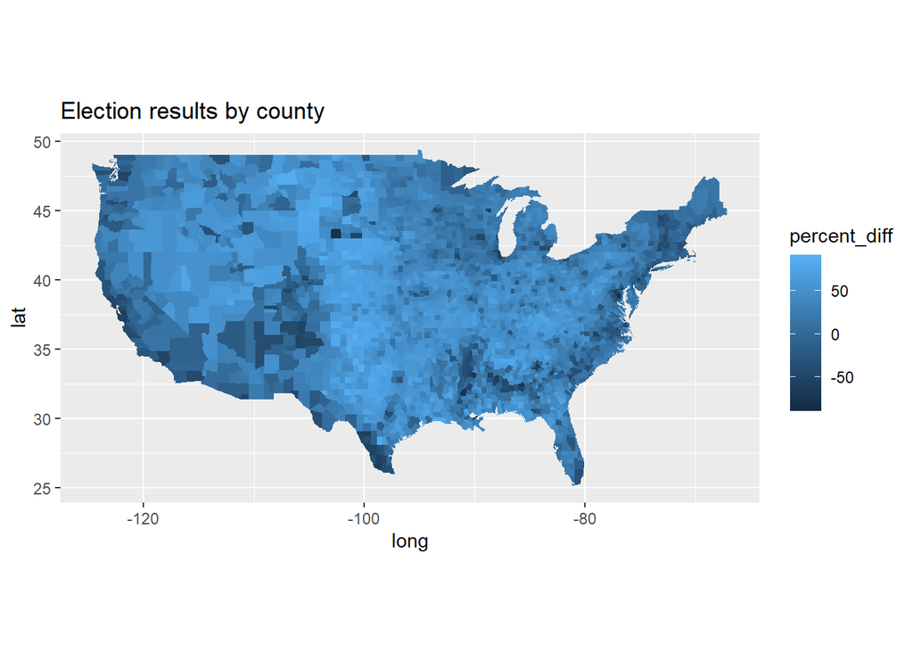

```r
ggplot(data = map_county_per_diff, mapping = aes(x = long, y = lat, group = group)) +
    geom_polygon(aes(fill = percent_diff)) +
    coord_quickmap() +
    labs(title = "Election results by county")
```

Great, we got a map! There are two things we can do to improve on it:

1. The color scale is currently different shades of blue. Something more informative would be counties that voted very Republican being red, those that voted very Democrat being blue, and those that voted evenly being white.
2. The “lat” and “long” axes, as well as the grey background with grid lines, are not helpful for interpreting maps.

Let’s change the color scale first. Amend the map plotting code to the following (see `?scale_fill_gradient2` to understand how it works):

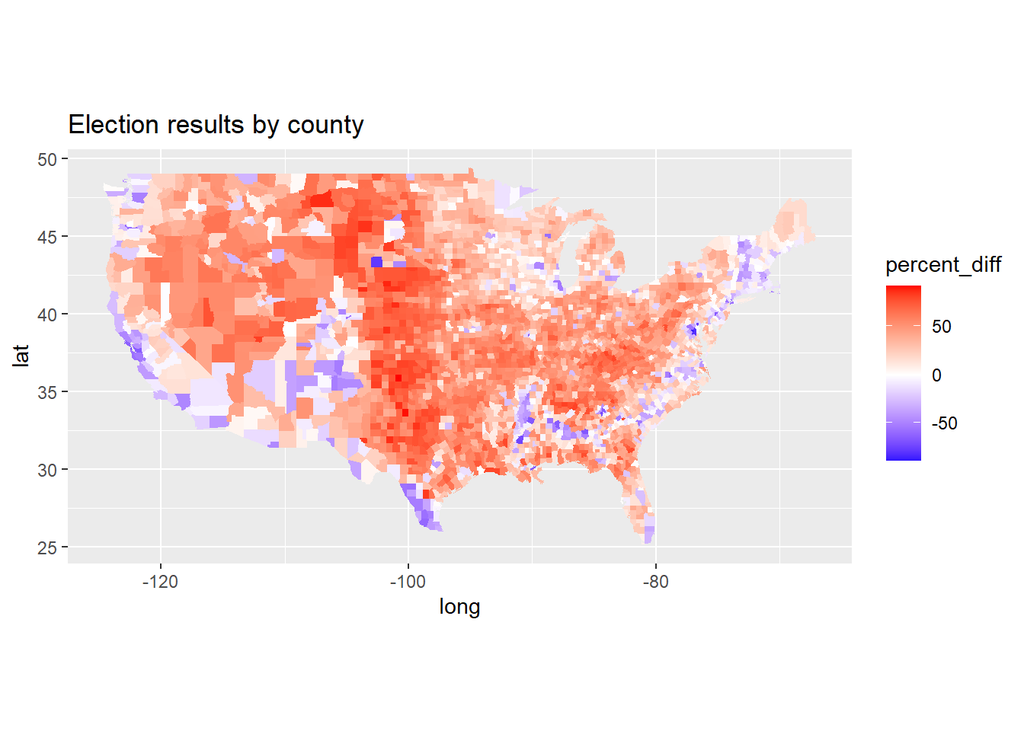

```r
ggplot(data = map_county_per_diff, mapping = aes(x = long, y = lat, group = group)) +
    geom_polygon(aes(fill = percent_diff)) +
    scale_fill_gradient2(low = "blue", high = "red") +
    coord_quickmap() +
    labs(title = "Election results by county")
```

To remove parts of the plot which are not helpful, type in the following code in the same chunk before the `ggplot` call:

```r
map_theme <- theme(
    axis.title.x = element_blank(),
    axis.text.x  = element_blank(),
    axis.ticks.x = element_blank(),
    axis.title.y = element_blank(),
    axis.text.y  = element_blank(),
    axis.ticks.y = element_blank(),
    panel.background = element_rect(fill = "white")
)
```

Next, add `map_theme` to the `ggplot` function call:

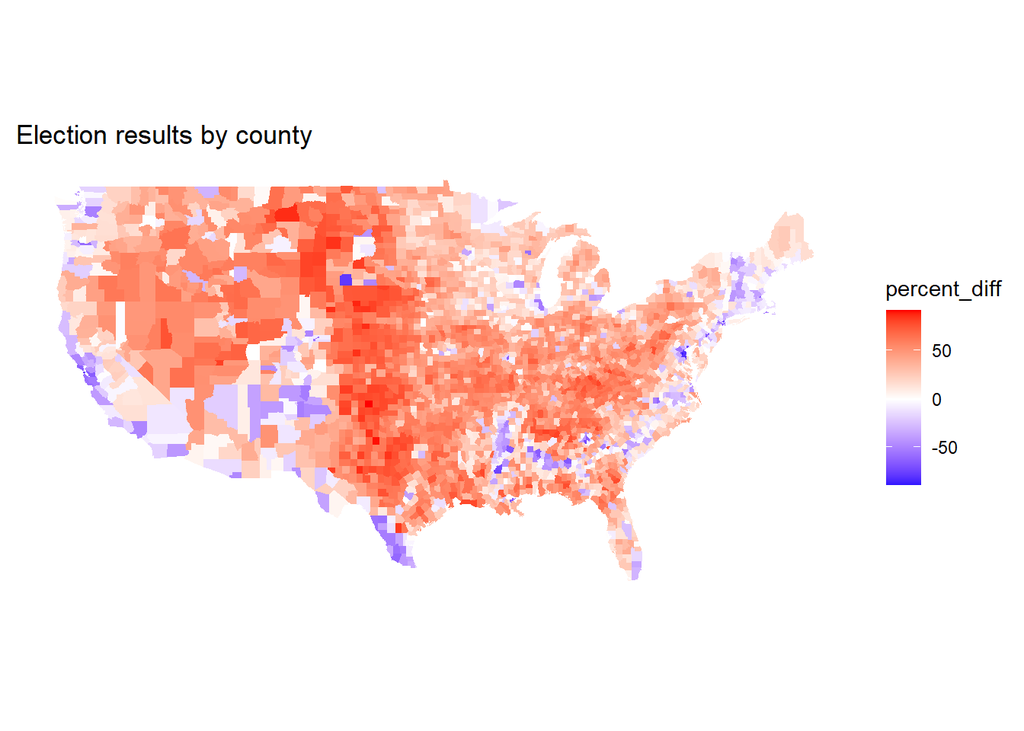

```r
ggplot(data = map_county_per_diff, mapping = aes(x = long, y = lat, group = group)) +
    geom_polygon(aes(fill = percent_diff)) +
    scale_fill_gradient2(low = "blue", high = "red") +
    coord_quickmap() +
    labs(title = "Election results by county") +
    map_theme
```

Play around with the labels, theme and color scales. Do any of the counties stand out to you? How can we modify the code above to draw a map of just one state?

## Optional material

### County map with state boundaries

To make the map better, we could draw state boundaries as well. Create a new code chunk and type in the following code. (Compare this code with the code in the previous chunk and try to figure out how the state boundaries were drawn.)

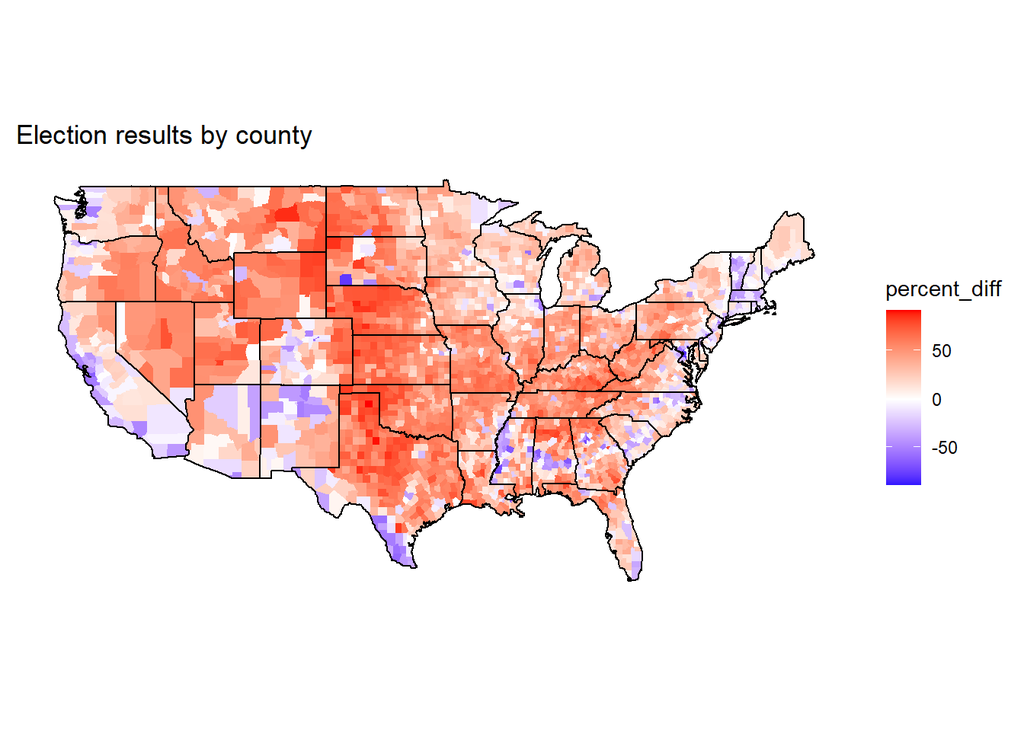

```r
map_state <- map_data("state")
ggplot(data = map_county_per_diff, mapping = aes(x = long, y = lat, group = group)) +
    geom_polygon(aes(fill = percent_diff)) +
    geom_polygon(data = map_state, fill = NA, color = "black") +
    scale_fill_gradient2(low = "blue", high = "red") +
    coord_quickmap() +
    labs(title = "Election results by county") +
    map_theme
```

(If you’re curious, that very blue spot in the middle of the country is Oglala County, South Dakota. From [Wikipedia](https://en.wikipedia.org/wiki/Oglala_Lakota_County,_South_Dakota#Politics): “The counties surrounding Oglala Lakota County are predominantly Republican, but, like most Native American counties, Oglala Lakota is heavily Democratic, giving over 75 percent of the vote to every Democratic presidential nominee in every election back to 1984, making it one of the most Democratic counties in the United States. No Republican has carried the county in a presidential election since 1952.”)

### State-level map

Let’s try to make the same map but at the state level, instead of at the county level. Make a new dataframe containing state-level data:

```r
state_df <- df %>% group_by(state) %>%
    summarize(votes_dem = sum(votes_dem),
              votes_gop = sum(votes_gop),
              total_votes = sum(total_votes)) %>%
    mutate(diff = votes_gop - votes_dem,
           percent_diff = diff / total_votes)
```

Notice that `state_df` and `map_state` contain their data on state differently: it’s abbreviated in `state_df`, while its the full name in `map_state`. We’ll need to do some data wrangling/transformation to get them to match.

R has 2 built-in variables, `state.abb` and `state.name`, which can help us. First, let’s augment these variables with “District of Columbia”:

```r
state_abb <- c(state.abb, "DC")
state_name <- c(state.name, "District of Columbia")
```

Next, we use the following line of code to add a new column to `state_df` which has the state name in full. (See `?match` to figure out what is going on here. We also have to use `tolower()` as the state names are all in small letters in the `map_state` dataset.)

```r
state_df$region <- tolower(state_name[match(state_df$state, state_abb)])
```

We are now in a position to join the datasets:

```r
combined_state_df <- map_state %>% left_join(state_df, by = "region")
```

The commands for plotting are almost the same as for the county map:

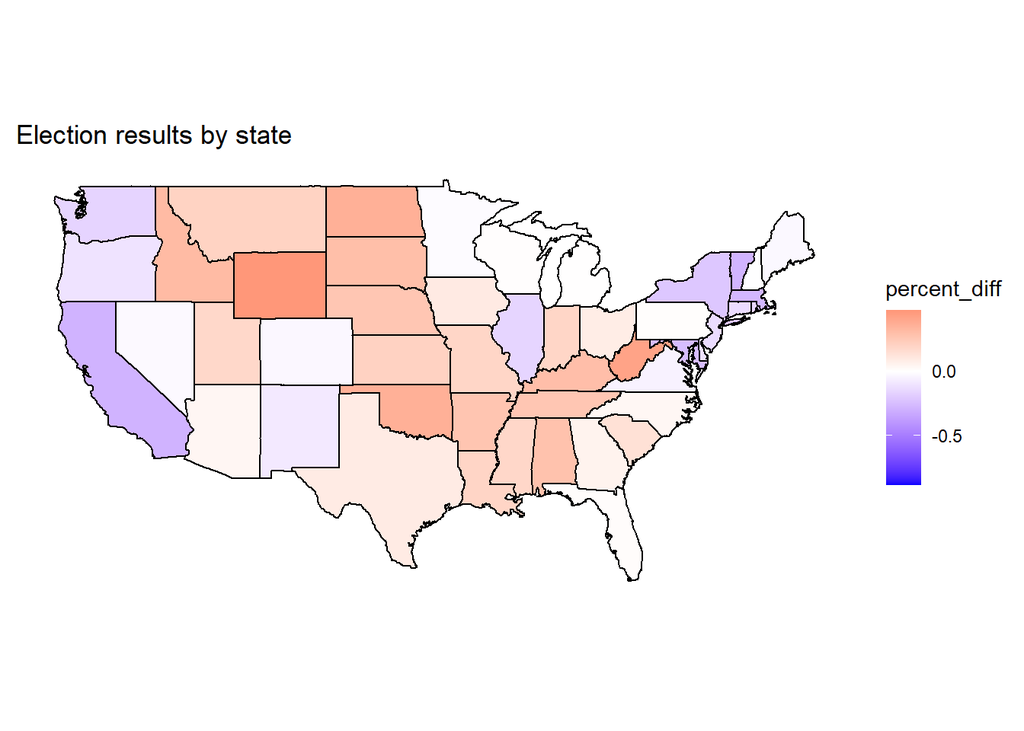

```r
ggplot(data = combined_state_df, mapping = aes(x = long, y = lat, group = group)) +
    geom_polygon(aes(fill = percent_diff)) +
    geom_polygon(fill = NA, color = "black") +
    scale_fill_gradient2(low = "blue", high = "red") +
    coord_quickmap() +
    labs(title = "Election results by state") +
    map_theme
```

We can also plot the state labels on the map (notice that the `group` can no longer be in the `ggplot()` call):

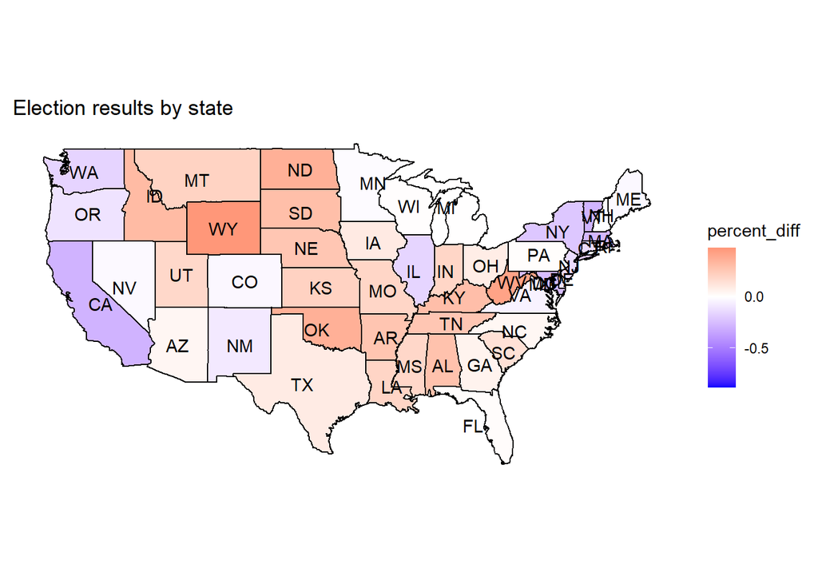

```r
state_names <- combined_state_df %>% group_by(state) %>%
    summarize(lat = 0.5 * (max(lat) + min(lat)),
              long = 0.5 * (max(long) + min(long)))

ggplot(data = combined_state_df, mapping = aes(x = long, y = lat)) +
    geom_polygon(aes(group = group, fill = percent_diff)) +
    geom_polygon(aes(group = group), fill = NA, color = "black") +
    geom_text(data = state_names,
              mapping = aes(x = long, y = lat, label = state)) +
    scale_fill_gradient2(low = "blue", high = "red") +
    coord_quickmap() +
    labs(title = "Election results by state") +
    map_theme
```